# WiDS : Sentiment Analysis Workshop Part 1

Ankita Guha

8/12/2023

## Installing Libraries

```r
#Installing Libraries
library(plyr)
library(tidytext)
library(janeaustenr)
library(stringr)
#library(rJava)
#library(qdap)
library(dplyr)
library(tm)
```

```r
library(NLP)
library(wordcloud)
library(plotrix)
#library(dendextend)
library(ggplot2)
#library(ggthemes)
#library(RWeka)
library(reshape2)
library(quanteda)
library(latexpdf)
```

## Reading the Data File

```r
setwd("~/Sentiment Analysis Workshop - WiDS")
AmazonReviews <- read.csv('./data/amazon_reviews.csv')
```

## Removing any missing values that might be present in the dataframe

```r
AmazonReviews <- na.omit(AmazonReviews)
```

## Sneakpeak of the Data

```r
head(AmazonReviews)
```

```
##   X reviewerName overall
## 1 0                    4
## 2 1         0mie       5
## 3 2          1K3       4
## 4 3          1m2       5
## 5 4 2&amp;1/2Men       5
## 6 5      2Cents!       5
##                                                                                                                                                                                                                                                                                                          …
## 1                                                                                                                                                                                                                                                                                                        …
## 2                                                                                                                                                                                       Purchased this for my device, it worked as advertised. You can never have too much phone memory, since I download…
## 3                                                                                                                                                                               it works as expected. I should have sprung for the higher capacity.  I think its made a bit cheesier than the earlier ver…
## 4 This think has worked out great.Had a diff. bran 64gb card and if went south after 3 months.This one has held up pretty well since I had my S3, now on my Note3.*** update 3/21/14I've had this for a few months and have had ZERO issue's since it was transferred from my S3 to my Note3 and into a n…
## 5                                                   Bought it with Retail Packaging, arrived legit, in a orange envelope, english version not asian like the picture shows. arrived quickly, bought a 32 and 16 both retail packaging for my htc one sv and Lg Optimus, both cards in working order, prob…
## 6                                                           It's mini storage.  It doesn't do anything else and it's not supposed to.  I purchased it to add additional storage to my Microsoft Surface Pro tablet which only come in 64 and 128 GB.  It does what it's supposed to and SanDisk has a lon…
##   reviewTime day_diff helpful_yes helpful_no total_vote score_pos_neg_diff
## 1 2014-07-23      138           0          0          0                  0
## 2 2013-10-25      409           0          0          0                  0
## 3 2012-12-23      715           0          0          0                  0
## 4 2013-11-21      382           0          0          0                  0
## 5 2013-07-13      513           0          0          0                  0
## 6 2013-04-29      588           0          0          0                  0
##   score_average_rating wilson_lower_bound
## 1                    0                  0
## 2                    0                  0
## 3                    0                  0
## 4                    0                  0
## 5                    0                  0
## 6                    0                  0
```

## Columns within the Dataset

```r
names(AmazonReviews)
```

```
##  [1] "X"                    "reviewerName"         "overall"
##  [4] "reviewText"           "reviewTime"           "day_diff"
##  [7] "helpful_yes"          "helpful_no"           "total_vote"
## [10] "score_pos_neg_diff"   "score_average_rating" "wilson_lower_bound"
```

## Corpus

After loading the data set, we can load the text data as a Corpus. This helps in facilitating the next process of data cleaning and further processing for analysis.

```r
Reviews <- Corpus(VectorSource(AmazonReviews$reviewText))
```

## Text Preprocessing

### i) Conversion to Lower Case

```r
Reviews <- tm_map(Reviews, tolower)
```

### ii) Remove Punctuation

```r
Reviews <- tm_map(Reviews, removePunctuation)
```

### iii) Remove Stopwords & Remove Numbers

```r
# List of Standard English Stopwords
#stopwords("en")
```

```r
# Remove Stopwords
Reviews <- tm_map(Reviews, removeWords, stopwords("en"))
# Remove Numbers
Reviews <- tm_map(Reviews, removeNumbers)
```

### iv) Remove Context Specific Stop Words

```r
Reviews <- tm_map(Reviews, removeWords,c("amazon", "amazons"))
```

### v) Stemming Words

By this process of stemming, the derived words are essentially reduced to their root words.

```r
Reviews <- tm_map(Reviews, stemDocument)
```

Okay, now that we have accomplished some levels of data cleaning. Let’s try to see some of the data in our Corpus now.

```r
Reviews[[8]][1]
```

```
## $content
## [1] "hard believ afford digit becom gb devic one quarter sie postag stamp scienc fiction less generat agoi pick portabl music didnt want schlep risk phone ipod work great sd card readersselect confid"
```

```r
Reviews[[2]][1]
```

```
## $content
## [1] "purchas devic work advertis can never much phone memori sinc download lot stuff brainer"
```

```r
Reviews[[7]][1]
```

```
## $content
## [1] "phone never skip beat file transfer speedi corrupt issu memori fade issu expect sandisk brand great card entrust precious file slight cheaper piec crap lose everyth can forgiv spend extra coupl buck trust product goe good qa"
```

```r
Reviews[[3]][1]
```

```
## $content
## [1] "work expect sprung higher capac think made bit cheesier earlier version paint look clean"
```

```r
Reviews[[6]][1]
```

```
## $content
## [1] "mini storag doesnt anyth els suppos purchas add addit storag microsoft surfac pro tablet come gb suppos sandisk long stand reput speak"
```

```r
Reviews[[5]][1]
```

```
## $content
## [1] "bought retail packag arriv legit orang envelop english version asian like pictur show arriv quick bought retail packag htc one sv lg optimus card work order probabl best price youll get nice sd card"
```

## Exploratory Text Analysis

Let’s next identify the most frequently used words in overall Customers Reviews.

## Create DTM & TDM from Corpus

This decides the Document Term Matrix that can help to identify the frequency of terms occurring in the corpuses. In a DTM, Rows correspond to Documents and Columns corresponds to Terms. In a TDM the rows of the matrix represents the sentences from the data & the columns of the Matrix represents the words. The TDM is a transpose of DTM.

```r
Reviews_DTM <- DocumentTermMatrix(Reviews)
Reviews_TDM <- TermDocumentMatrix(Reviews)
```

Let’s use the TDM to identify the frequent terms, by converting them to matrix

```r
# Convert TDM to Matrix
Reviews_TDM <- as.matrix(Reviews_TDM)

# Sum Rows and Frequency Data Frame
Reviews_Term_Freq <- rowSums(Reviews_TDM)

# Sort term_frequency in descending order
Reviews_Term_Freq <- sort(Reviews_Term_Freq, decreasing = T)

# View the top 10 most common words
Reviews_Term_Freq[1:20]
```

```
##    card    work     use   phone   great  memori sandisk     one  galaxi   price
##    5537    2774    2209    1909    1457    1378    1315    1120    1027     948
##   speed    fast     can    good problem samsung  bought    just  storag  tablet
##     924     907     897     895     848     836     832     820     756     727
```

## Visualization

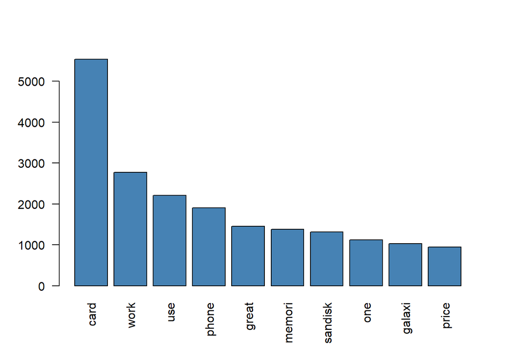

```r
# Plot a barchart of the 10 most common words
barplot(Reviews_Term_Freq[1:10], col = "steel blue", las = 2)
```

## Word Clouds

### Top 100

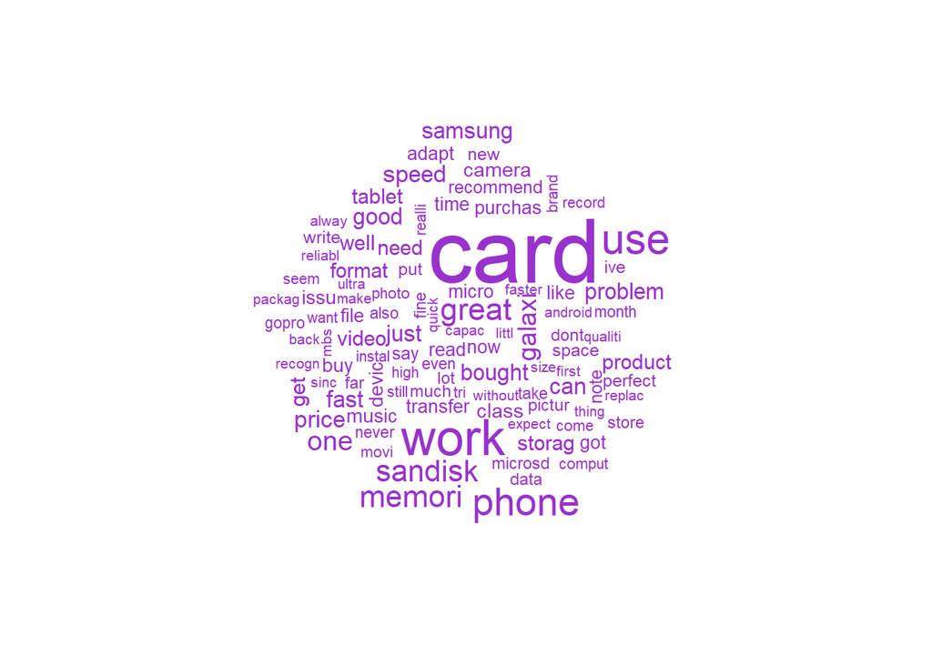

```r
Reviews_Term_Freq <- data.frame(term = names(Reviews_Term_Freq), num = Reviews_Term_Freq)
# Create a wordcloud for the values in word_freqs
wordcloud(Reviews_Term_Freq$term, Reviews_Term_Freq$num, max.words = 100, colors = "darkorchid")
```

### Top 50

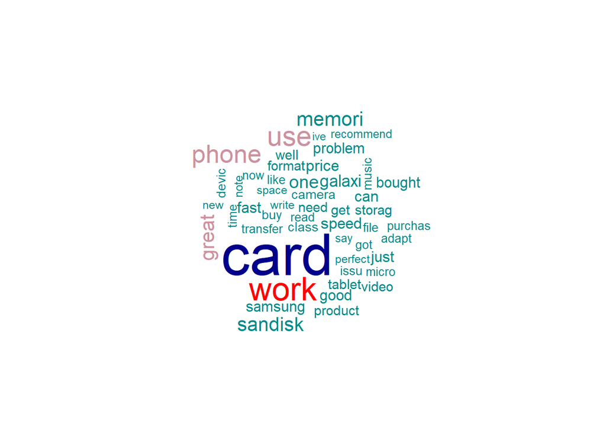

```r
# Print the word cloud with the specified colors
wordcloud(Reviews_Term_Freq$term, Reviews_Term_Freq$num,
  max.words = 50, colors = c("darkcyan","pink3","red", "darkblue"))
```

## Bi-Grams

### Top 10 Bi Grams for the Review

```r
# Removing NA values from the data frame
AmazonReviews <- na.omit(AmazonReviews)

review_bigram <- tokens(AmazonReviews$reviewText) %>%
    tokens_remove("\\p{P}", valuetype = "regex", padding = TRUE) %>% #removes punctuation
    tokens_remove(stopwords("english"), padding  = TRUE) %>%
    tokens_ngrams(n = 2) %>%
    dfm()
topfeatures(review_bigram)
```

```
##        sd_card    memory_card samsung_galaxy    works_great       class_10
##            690            529            479            476            416
##       micro_sd    galaxy_note      galaxy_s3      galaxy_s4   microsd_card
##            353            266            242            192            159
```

## Tri-Grams

Note that **galaxy_note_2** and **galaxy_note_ii** is in 2 different format.

```r
review_trigram <- tokens(AmazonReviews$reviewText) %>%
    tokens_remove("[\\p{P}\\p{S}]", valuetype = "regex", padding = TRUE) %>% #removes punctuation & symbols
    tokens_remove(stopwords("english"), padding  = TRUE) %>%
    tokens_ngrams(n = 3) %>%
    dfm()
topfeatures(review_trigram)
```

```
##       micro_sd_card samsung_galaxy_note   samsung_galaxy_s3       galaxy_note_2
##                 177                 116                 108                  91
##   samsung_galaxy_s4        gopro_hero_3       class_10_card  samsung_galaxy_tab
##                  79                  75                  59                  47
##      galaxy_note_ii      micro_sd_cards
##                  45                  38
```

## Four-Grams

```r
review_4gram <- tokens(AmazonReviews$reviewText) %>%
    tokens_remove("[\\p{P}\\p{S}]", valuetype = "regex", padding = TRUE) %>% #removes punctuation & symbols
    tokens_remove(stopwords("english"), padding  = TRUE) %>%
    tokens_ngrams(n = 4) %>%
    dfm()
topfeatures(review_4gram)
```

```
##  samsung_galaxy_note_2    sandisk_ultra_32_gb samsung_galaxy_note_ii
##                     35                     24                     23
##   samsung_galaxy_tab_2  ultra_32_gb_microsdhc  64_gb_microsdxc_class
##                     22                     20                     19
##  gb_microsdxc_class_10     gopro_hero_3_black  ultra_64_gb_microsdxc
##                     18                     16                     16
##    sandisk_ultra_64_gb
##                     15
```

*Note*: 1. These word grams are created using the actual data frame and not from the Corpus. 2. If you would like to see more levels of granularity keep on increasing the word grams to see how various words are appearing within the data set.

```r
library(cluster)
library(factoextra)
```

## Feature Frequency for Bi-Gram

```r
library(quanteda.textstats)
```

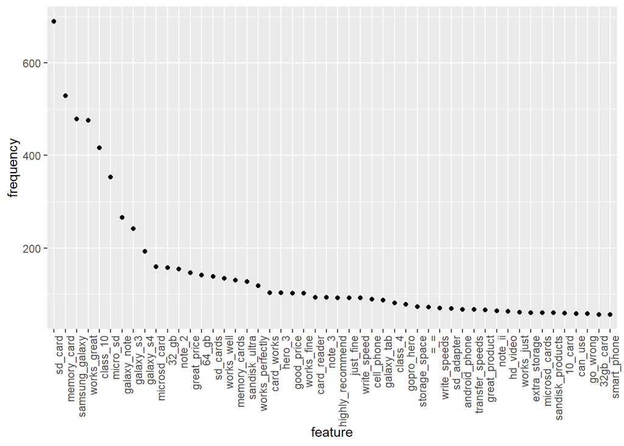

```r
rb1 <- textstat_frequency(review_bigram, n = 50)

# Sort by reverse frequency order
rb1$feature <- with(rb1, reorder(feature, -frequency))

ggplot(rb1, aes(x = feature, y = frequency), colour = frequency) +
    geom_point() + theme_gray() +
    theme(axis.text.x = element_text(angle = 90, hjust = 1))
```

```r
# Lolypop Chart
library(ggpubr)
```

### Top 20 Bi-Grams

```r
# Picking top 20 features and ranking their frequency
rb1 <- rb1[c(1:20),c(1:4)]
```

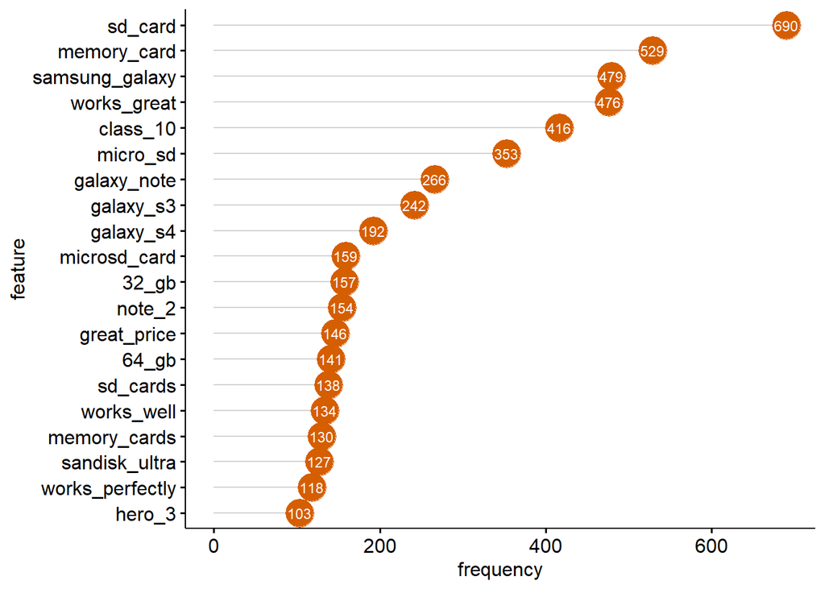

```r
ggdotchart(rb1, x = "feature", y = "frequency",
           #color = "rank",                              # Color by groups
           color = c("#D55E00"),                         # Custom color palette
           sorting = "descending",                       # Sort value in descending order
           add = "segments",                             # Add segments from y = 0 to dots
           rotate = TRUE,                                # Rotate vertically
           #group = "rank",                              # Order by groups
           dot.size = 8,                                 # Large dot size
           label = (rb1$frequency),                      # Add values as dot labels
           font.label = list(color = "white", size = 9,
                             vjust = 0.5),               # Adjust label parameters
           ggtheme = theme_pubr()                        # ggplot2 theme
           )
```

## Feature Frequency for Tri-Gram

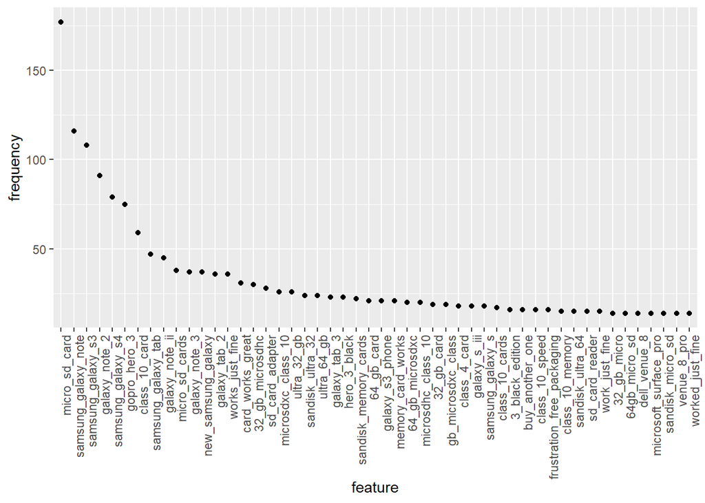

```r
rt1 <- textstat_frequency(review_trigram, n = 50)

# Sort by reverse frequency order
rt1$feature <- with(rt1, reorder(feature, -frequency))

ggplot(rt1, aes(x = feature, y = frequency), colour = frequency) +
    geom_point() + theme_gray() +
    theme(axis.text.x = element_text(angle = 90, hjust = 1))
```

### Top 20 Tri-Grams

```r
#rt1 <- rt1[c(14,22,26:27,33,37,40,49,52,56,60,76,74,102,112,126,142),c(1:5)]
rt1 <- rt1[c(1:20),c(1:5)]
```

### Tri-Gram Visualization of Top Frequency Words

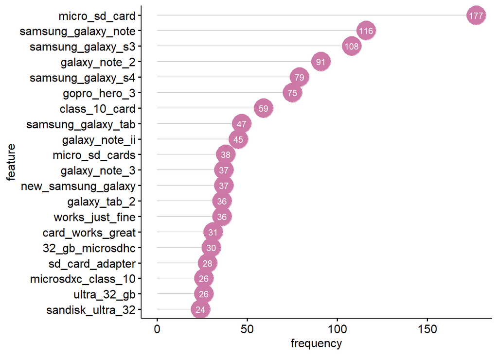

```r
ggdotchart(rt1, x = "feature", y = "frequency",
           #color = "rank",                              # Color by groups
           color = c("#CC79A7"),                         # Custom color palette
           sorting = "descending",                       # Sort value in descending order
           add = "segments",                             # Add segments from y = 0 to dots
           rotate = TRUE,                                # Rotate vertically
           #group = "rank",                              # Order by groups
           dot.size = 9,                                 # Large dot size
           label = (rt1$frequency),                      # Add values as dot labels
           font.label = list(color = "white", size = 9,
                             vjust = 0.5),               # Adjust label parameters
           ggtheme = theme_pubr()                        # ggplot2 theme
           )
```

Let’s find words which occurs frequently within the corpus. In this case we have one corpus, so let’s check the range of low and high frequency words could vary depending on the occurrences of these words within the corpus.

```r
library(NLP)
library(tm)


# Terms occurring within the range of 100 to 200
#findFreqTerms(Reviews_DTM, lowfreq = 100, highfreq = 200)

# Terms occurring at least 500 times within the Corpus. Decreasing the number of iteration will increase the number of words within the whole corpus and vice versa
findFreqTerms(Reviews_DTM, 500)
```

```
##  [1] "issu"      "can"       "devic"     "memori"    "phone"     "purchas"
##  [7] "work"      "card"      "note"      "now"       "one"       "transfer"
## [13] "well"      "bought"    "get"       "like"      "price"     "sandisk"
## [19] "storag"    "tablet"    "file"      "good"      "great"     "product"
## [25] "music"     "fast"      "galaxi"    "adapt"     "camera"    "class"
## [31] "recommend" "speed"     "video"     "read"      "problem"   "use"
## [37] "need"      "got"       "buy"       "micro"     "samsung"   "format"
## [43] "just"      "time"
```

### Words Association : Correlation

For any given word, the function **findAssocs()** calculates its correlation with every other word in DTM. This function will return a list of all other terms that meets or exceed the minimum threshold. Scores range from 0 to 1. A score of 1 means that two words always appear together in documents, while a score approaching 0 means the terms seldom appear in the same document. Try to increase or decrease the range and see how the words associations varies.

```r
#You can also use specific words to check the variability and associations of those words from the Corpus
#findAssocs(Reviews_DTM, c("samsung", "card", "phone", "tablet"), corlimit = 0.2)

# Find associations of words that occur at least 600 times with a Correlation of equal to or greater than 0.25
findAssocs(Reviews_DTM, terms = findFreqTerms(Reviews_DTM, 600), corlimit = 0.25)
```

```
## $issu
##         fix    cardsfor    cardsupd   courseupd       didgo experiencei
##        0.36        0.34        0.34        0.34        0.34        0.34
##      farupd   fixedgood    flagship       goesi   implement    inadvert
##        0.34        0.34        0.34        0.34        0.34        0.34
##     luckbtw       patch    prepatch  problemaft reviewthank       romso
##        0.34        0.34        0.34        0.34        0.34        0.34
##    sensewel  serviceupd     shocker     starsto      thison         too
##        0.34        0.34        0.34        0.34        0.34        0.34
##     unpatch         rep       solut        solv       begin      approv
##        0.34        0.33        0.27        0.27        0.26        0.25
##
## $can
## exfat
##  0.26
##
## $memori
## numeric(0)
##
## $phone
##             restart              aelago         againdecemb          backdecemb
##                0.42                0.40                0.40                0.40
##             blackto          carddecemb                cord disappointingdecemb
##                0.40                0.40                0.40                0.40
##               liesi     mntextsdcardmus        musictuesday            okdecemb
##                0.40                0.40                0.40                0.40
##        problemtoday        reformattedi       sdsdqgaffpand            sharpest
##                0.40                0.40                0.40                0.40
##             subfold            thursday      togetherdecemb           yetdecemb
##                0.40                0.40                0.40                0.40
##            zenfolio                morn            poweramp           disappear
##                0.40                0.36                0.36                0.33
##              folder               notif           afternoon               reset
##                0.32                0.32                0.32                0.29
##                play          sdsdqgaffp              messag             counter
##                0.28                0.28                0.28                0.28
##                shed         availableth             corrupt                show
##                0.28                0.28                0.27                0.26
##              novemb
##                0.26
```

[output cut: 263 more lines]

```
##  komputerbay    masochist         ntsf    playeronc sdmicrosdmmc        sixit
##         0.40         0.40         0.40         0.40         0.40         0.40
##    softpedia  tabletswith     therebuy       tieron        towni   unconscion
##         0.40         0.40         0.40         0.40         0.40         0.40
## unfortunatey       window       crippl       intent   readerwrit     gracious
##         0.40         0.36         0.35         0.32         0.31         0.31
##          tri    wednesday      readeri        spoke       licens       unopen
##         0.30         0.30         0.30         0.30         0.30         0.28
##   sandiskupd       partit       master         quot        gfrsd       iogear
##         0.28         0.28         0.28         0.28         0.28         0.28
##      deliber      confirm     incompat       easeus         util         ntfs
##         0.28         0.27         0.27         0.26         0.25         0.25
##
## $just
## numeric(0)
```

## Sentiment Analysis : Corpus as Vector Source

```r
library(SentimentAnalysis)
```

## Dataframe Preprocessing

```r
#any(is.na(Reviews))

# Create a Vector Source
ReviewsCorpus <- Corpus(VectorSource(as.vector(Reviews)))
```

## Corpus Preprocessing

```r
# Convert to Lower Case
ReviewsCorpus = tm_map(ReviewsCorpus, tolower)
# Remove Punctuation
ReviewsCorpus = tm_map(ReviewsCorpus, removePunctuation)
# Remove Stopwords
ReviewsCorpus = tm_map(ReviewsCorpus, removeWords, stopwords("english"))
# Stem Document
ReviewsCorpus = tm_map(ReviewsCorpus, stemDocument)
```

### Overall Sentiment Co-efficient with various Dictionaries

### QDAP Dictionary

The QDAP Dictionary has 3 levels of Sentiments classified in 3 directions (positive, negative and neutral). However in this case with all the Reviews in the Corpus we got positive and neutral reviews only.

```r
# Sentiment Analysis of Corpus: Reviews
sentiment <- analyzeSentiment(ReviewsCorpus)
# Obtaining Binary Response from the Corpus
binaryResponse <- convertToBinaryResponse(sentiment)$SentimentQDAP
binaryResponse
```

```
## [1] positive positive positive
## Levels: negative positive
```

```r
# Extracting dictionary based sentiment
dict <- sentiment$SentimentQDAP
dict
```

```
## [1] 0.1380326 0.0000000 0.0000000
```

```r
# View sentiment direction (i.e. positive, neutral and negative)
responseQDAP <- convertToDirection(sentiment$SentimentQDAP)
responseQDAP
```

```
## [1] positive neutral  neutral
## Levels: negative neutral positive
```

### Explore QDAP Dictionary Response for Models Performance

Compare sentiment values to existing Response Variable. Evaluate various Dictionaries performance based on changing the response to positive, negative and neutral.

```r
#Exploring Response as per Dictionary QDAP
responseall <- c(+1, 0, -1)
# Gives all the Stats to Evaluate the Models
compareToResponse(sentiment, responseall)
```

```
##                               WordCount SentimentGI NegativityGI PositivityGI
## cor                        8.660254e-01  0.86602540   0.86602540   0.86602540
## cor.t.statistic            1.732051e+00  1.73205081   1.73205081   1.73205081
## cor.p.value                3.333333e-01  0.33333333   0.33333333   0.33333333
## lm.t.value                 1.732051e+00  1.73205081   1.73205081   1.73205081
## r.squared                  7.500000e-01  0.75000000   0.75000000   0.75000000
## RMSE                       6.882593e+04  0.77900464   0.78152618   0.74596783
## MAE                        3.973767e+04  0.63527974   0.63744397   0.60605705
## Accuracy                   6.666667e-01  0.66666667   0.66666667   0.66666667
## Precision                           NaN         NaN          NaN          NaN
## Sensitivity                0.000000e+00  0.00000000   0.00000000   0.00000000
## Specificity                1.000000e+00  1.00000000   1.00000000   1.00000000
## F1                                  NaN         NaN          NaN          NaN
## BalancedAccuracy           5.000000e-01  0.50000000   0.50000000   0.50000000
## avg.sentiment.pos.response 5.960600e+04  0.04708039   0.04383404   0.09091443
## avg.sentiment.neg.response 1.000000e+00  0.00000000   0.00000000   0.00000000
##                            SentimentHE NegativityHE PositivityHE SentimentLM
## cor                        0.866025404  0.866025404   0.86602540 0.866025404
## cor.t.statistic            1.732050808  1.732050808   1.73205081 1.732050808
## cor.p.value                0.333333333  0.333333333   0.33333333 0.333333333
## lm.t.value                 1.732050808  1.732050808   1.73205081 1.732050808
## r.squared                  0.750000000  0.750000000   0.75000000 0.750000000
## RMSE                       0.809832587  0.813891230   0.80724899 0.815610096
## MAE                        0.661202965  0.664535991   0.65907229 0.665942461
## Accuracy                   0.666666667  0.666666667   0.66666667 0.666666667
## Precision                          NaN          NaN          NaN         NaN
## Sensitivity                0.000000000  0.000000000   0.00000000 0.000000000
## Specificity                1.000000000  1.000000000   1.00000000 1.000000000
## F1                                 NaN          NaN          NaN         NaN
## BalancedAccuracy           0.500000000  0.500000000   0.50000000 0.500000000
## avg.sentiment.pos.response 0.008195552  0.003196014   0.01139157 0.001086309
## avg.sentiment.neg.response 0.000000000  0.000000000   0.00000000 0.000000000
##                            NegativityLM PositivityLM RatioUncertaintyLM
## cor                          0.86602540   0.86602540        0.866025404
## cor.t.statistic              1.73205081   1.73205081        1.732050808
## cor.p.value                  0.33333333   0.33333333        0.333333333
## lm.t.value                   1.73205081   1.73205081        1.732050808
## r.squared                    0.75000000   0.75000000        0.750000000
## RMSE                         0.80046220   0.79959388        0.811328325
## MAE                          0.65344082   0.65271661        0.662433277
```

[output cut: 9 more lines]

```
## cor                           0.86602540     0.86602540     0.86602540
## cor.t.statistic               1.73205081     1.73205081     1.73205081
## cor.p.value                   0.33333333     0.33333333     0.33333333
## lm.t.value                    1.73205081     1.73205081     1.73205081
## r.squared                     0.75000000     0.75000000     0.75000000
## RMSE                          0.76223091     0.79519777     0.74265453
## MAE                           0.62065581     0.64903686     0.60302601
## Accuracy                      0.66666667     0.66666667     0.66666667
## Precision                            NaN            NaN            NaN
## Sensitivity                   0.00000000     0.00000000     0.00000000
## Specificity                   1.00000000     1.00000000     1.00000000
## F1                                   NaN            NaN            NaN
## BalancedAccuracy              0.50000000     0.50000000     0.50000000
## avg.sentiment.pos.response    0.06901628     0.02644471     0.09546099
## avg.sentiment.neg.response    0.00000000     0.00000000     0.00000000
```

```r
compareToResponse(sentiment, convertToBinaryResponse(responseall))
```

```
##                               WordCount SentimentGI NegativityGI PositivityGI
## Accuracy                   6.666667e-01  0.66666667   0.66666667   0.66666667
## Precision                           NaN         NaN          NaN          NaN
## Sensitivity                0.000000e+00  0.00000000   0.00000000   0.00000000
## Specificity                1.000000e+00  1.00000000   1.00000000   1.00000000
## F1                                  NaN         NaN          NaN          NaN
## BalancedAccuracy           5.000000e-01  0.50000000   0.50000000   0.50000000
## avg.sentiment.pos.response 5.960600e+04  0.04708039   0.04383404   0.09091443
## avg.sentiment.neg.response 1.000000e+00  0.00000000   0.00000000   0.00000000
##                            SentimentHE NegativityHE PositivityHE SentimentLM
## Accuracy                   0.666666667  0.666666667   0.66666667 0.666666667
## Precision                          NaN          NaN          NaN         NaN
## Sensitivity                0.000000000  0.000000000   0.00000000 0.000000000
## Specificity                1.000000000  1.000000000   1.00000000 1.000000000
## F1                                 NaN          NaN          NaN         NaN
## BalancedAccuracy           0.500000000  0.500000000   0.50000000 0.500000000
## avg.sentiment.pos.response 0.008195552  0.003196014   0.01139157 0.001086309
## avg.sentiment.neg.response 0.000000000  0.000000000   0.00000000 0.000000000
##                            NegativityLM PositivityLM RatioUncertaintyLM
## Accuracy                     0.66666667   0.66666667        0.666666667
## Precision                           NaN          NaN                NaN
## Sensitivity                  0.00000000   0.00000000        0.000000000
## Specificity                  1.00000000   1.00000000        1.000000000
## F1                                  NaN          NaN                NaN
## BalancedAccuracy             0.50000000   0.50000000        0.500000000
## avg.sentiment.pos.response   0.01983877   0.02092508        0.006350085
## avg.sentiment.neg.response   0.00000000   0.00000000        0.000000000
##                            SentimentQDAP NegativityQDAP PositivityQDAP
## Accuracy                      0.66666667     0.66666667     0.66666667
## Precision                            NaN            NaN            NaN
## Sensitivity                   0.00000000     0.00000000     0.00000000
## Specificity                   1.00000000     1.00000000     1.00000000
## F1                                   NaN            NaN            NaN
## BalancedAccuracy              0.50000000     0.50000000     0.50000000
## avg.sentiment.pos.response    0.06901628     0.02644471     0.09546099
## avg.sentiment.neg.response    0.00000000     0.00000000     0.00000000
```

## Trends visualizing the trend between Sentiment & Response

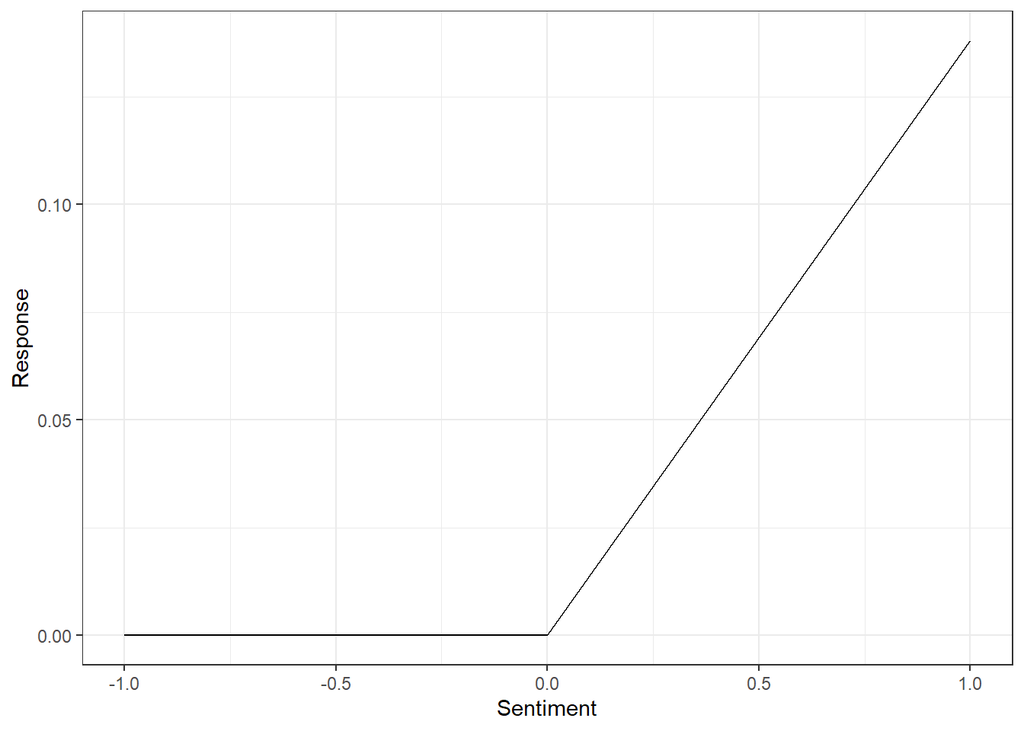

```r
plotSentiment(sentiment$SentimentQDAP, responseall,
                      xlab = "Sentiment", ylab = "Response")
```

### Plotting overall Sentiment Analysis with QDAP Dictionary

```r
unique(responseQDAP)
```

```
## [1] positive neutral
## Levels: negative neutral positive
```

```r
unique(responseall)
```

```
## [1]  1  0 -1
```

```r
dim(table(responseQDAP))
```

```
## [1] 3
```

```r
#dim(table(responseQDAP))

library(data.table)
```

### Visualizing the Responses in Vector Corpus from the Data Table

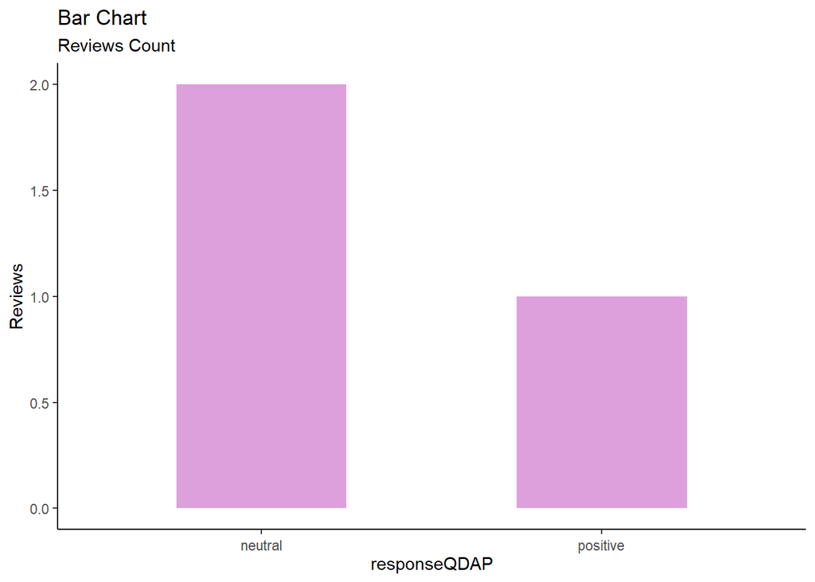

```r
DTQDAP <- data.table(responseQDAP)


#Number of Factors for the Reviews
DTQDAP <- DTQDAP %>%
  group_by(responseQDAP) %>%
  summarise(Reviews = length(responseQDAP))


#Visualization
library("RColorBrewer")
library(ggplot2)
theme_set(theme_classic())


g <- ggplot(DTQDAP, aes(responseQDAP, Reviews))
g + geom_bar(stat="identity", width = 0.5, fill="plum") +
      labs(title="Bar Chart",
           subtitle="Reviews Count") +
      theme(axis.text.x = element_text(angle=360, vjust=0.6))
```

**Note**: 1. Try out with the other Dictionaries and check out their direction level and responses.

### LM Dictionary

```r
sentimentLM <- sentiment$SentimentLM
```

### GI Dictionary

```r
sentimentGI <- sentiment$SentimentGI
```

### HE Dictionary

```r
sentimentHE <- sentiment$SentimentHE
```

## Sentiment Analysis : Using Corpus Only

```r
library(SentimentAnalysis)
sentimentC <- analyzeSentiment(Reviews)
# Remove NAs
sentimentC <- na.omit(sentimentC)

# Dictionary QDAP
sentimentQDAP_C <- sentimentC$SentimentQDAP

# Dictionary LM
SentimentLM_C <- sentimentC$SentimentLM

# Dictionary GI
SentimentGI_C <- sentimentGI <- sentimentC$SentimentGI

# Convert to Direction
convertToDirection(sentimentC$SentimentQDAP)
```

```
##    [1] negative positive positive positive positive positive positive positive
##    [9] positive positive positive positive neutral  positive negative positive
##   [17] positive positive positive negative positive positive positive positive
##   [25] neutral  positive positive positive positive positive positive positive
##   [33] positive positive negative positive positive positive positive positive
##   [41] positive positive negative negative positive positive positive negative
##   [49] positive neutral  positive positive positive positive positive positive
##   [57] positive positive positive positive negative positive positive positive
##   [65] negative positive positive positive positive positive positive positive
##   [73] neutral  positive positive positive positive positive positive positive
##   [81] positive neutral  positive positive neutral  positive positive positive
##   [89] positive positive positive negative positive positive positive positive
##   [97] positive positive positive positive positive positive positive positive
##  [105] positive positive positive positive positive positive positive neutral
##  [113] positive neutral  positive positive neutral  positive positive positive
```

[output cut: 601 more lines]

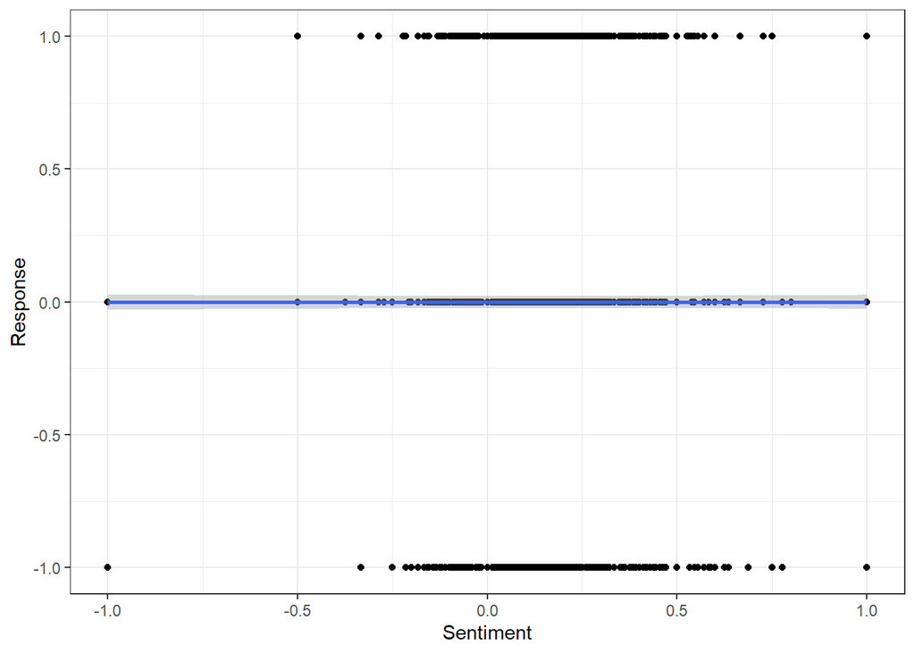

```r
#Exploring Response as per Dictionary QDAP
responseall <- c(-1, 0, +1)
plotSentimentResponse(sentimentC$SentimentQDAP, responseall)
```

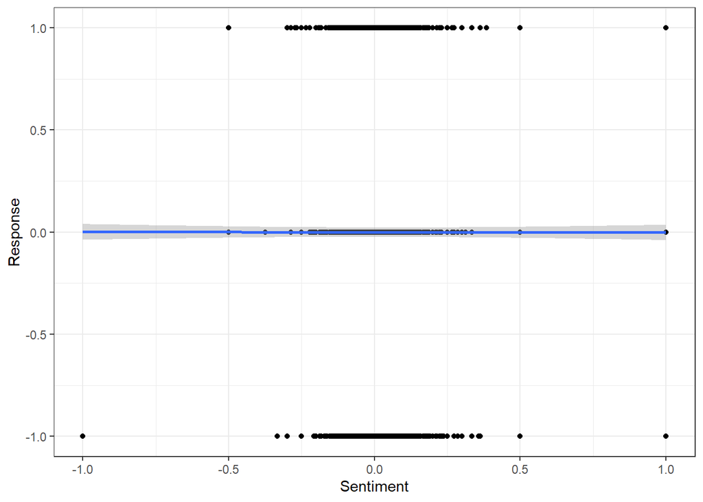

```r
plotSentimentResponse(sentimentC$SentimentLM, responseall)
```

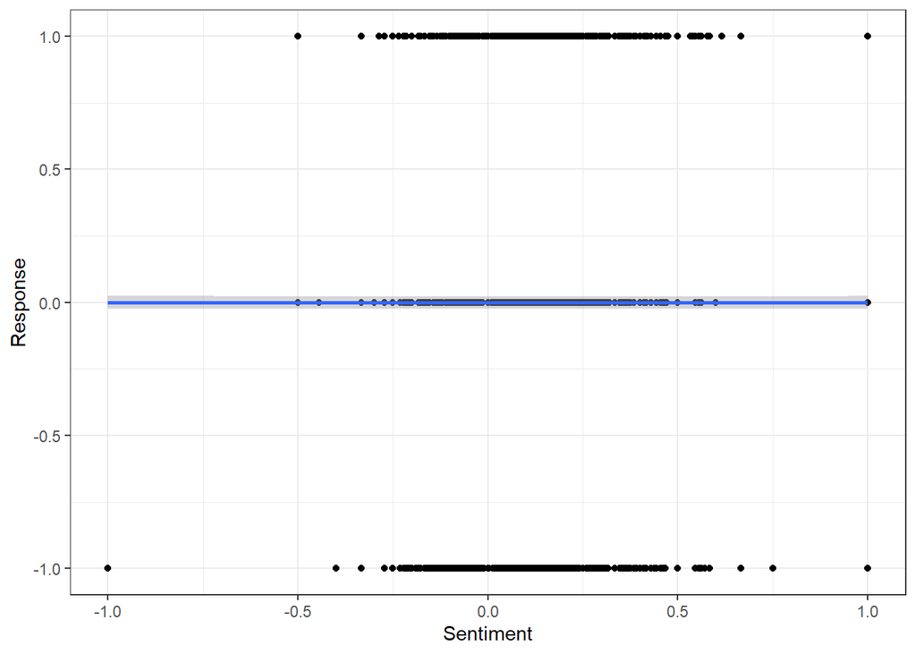

```r
plotSentimentResponse(sentimentC$SentimentGI, responseall)
```

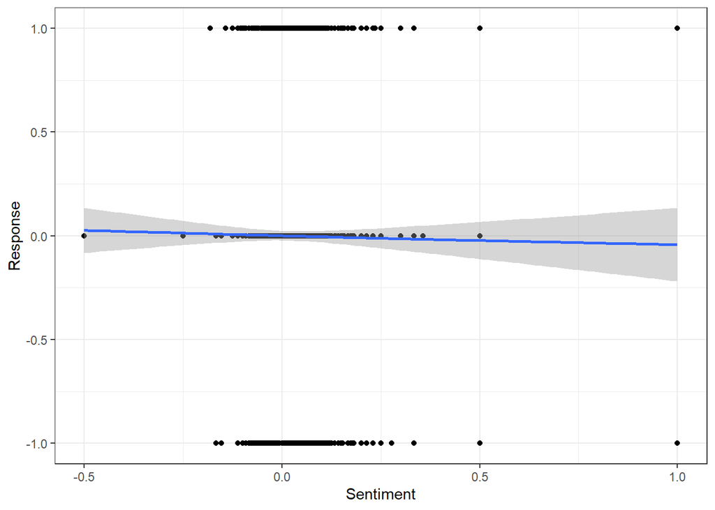

```r
plotSentimentResponse(sentimentC$SentimentHE, responseall)
```

```r
responseQDAP_C <- convertToDirection(sentimentC$SentimentQDAP)
unique(responseQDAP_C)
```

```
## [1] negative positive neutral
## Levels: negative neutral positive
```

```r
dim(table(responseQDAP_C))
```

```
## [1] 3
```

## Visualization of Sentiments with Corpus Only

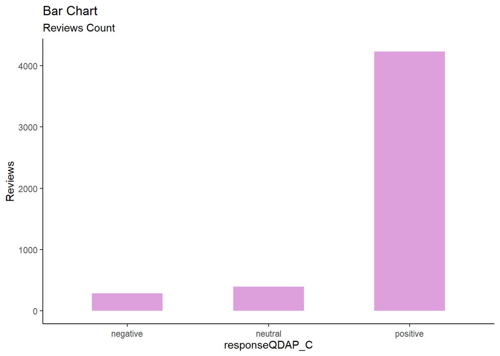

```r
DTQDAP <- data.table(responseQDAP_C)


#Number of Factors for the Reviews
DTQDAP <- DTQDAP %>%
  group_by(responseQDAP_C) %>%
  summarise(Reviews = length(responseQDAP_C))


#Visualization
library("RColorBrewer")
library(ggplot2)
theme_set(theme_classic())


g <- ggplot(DTQDAP, aes(responseQDAP_C, Reviews))
g + geom_bar(stat="identity", width = 0.5, fill="plum") +
      labs(title="Bar Chart",
           subtitle="Reviews Count") +
      theme(axis.text.x = element_text(angle=360, vjust=0.6))
```